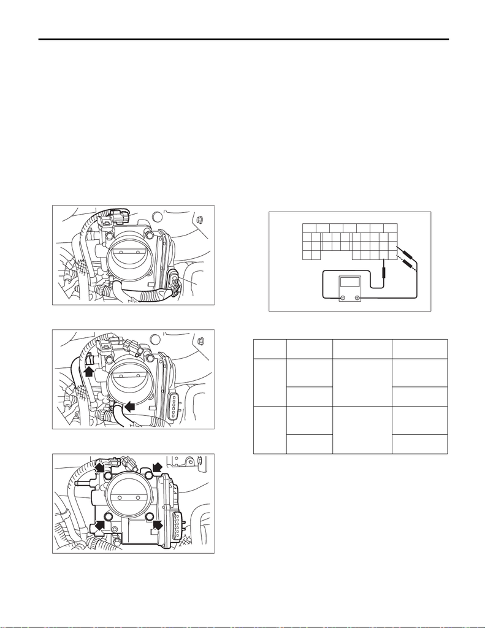

FU(STI)-15

Throttle Body

FUEL INJECTION (FUEL SYSTEMS)

2. Throttle Body

A: REMOVAL

1) Disconnect the ground cable from battery.

2) Lift up the vehicle.

3) Remove the under cover. <Ref. to EI-21, RE-

MOVAL, Front Under Cover.>

4) Drain approximately 3.0 L (3.2 US qt, 2.6 Imp qt)

of coolant. <Ref. to CO(STI)-13, DRAINING OF

ENGINE COOLANT, REPLACEMENT, Engine

Coolant.>

5) Remove the intercooler. <Ref. to IN(STI)-13,

REMOVAL, Intercooler.>

6) Disconnect the connector (A) from the throttle

position sensor, and the connector (B) from the

manifold pressure sensor.

7) Disconnect the engine coolant hose from throttle

body.

8) Remove the throttle body from the intake mani-

fold.

B: INSTALLATION

Install in the reverse order of removal.

NOTE:

Use a new gasket.

Tightening torque:

8 N·m (0.8 kgf-m, 5.9 ft-lb)

C: INSPECTION

1. THROTTLE SENSOR INSPECTION

(METHOD WITH CIRCUIT TESTER)

1) Remove the glove box. <Ref. to EI-63, REMOV-

AL, Glove Box.>

2) Turn the ignition switch to ON. (engine OFF)

3) Measure the voltage between ECM connector

terminals.

4) After inspection, install the related parts in the

reverse order of removal.

FU-05759

(B)

(A)

FU-05760

FU-05691

(A) To ECM connector

Throttle

sensor

Accelerator

pedal

Terminal No. Standard

Main

Not

depressed

(full closed)

18 (+) and 29 (–)

Approx. 0.6 V

Depressed

(full opened)

Approx. 3.96 V

Sub

Not

depressed

(full closed)

28 (+) and 29 (–)

Approx. 1.48 V

Depressed

(full opened)

Approx. 4.17 V

FU-04049

567

8

21

9

43

10

2627

28

1617

V

(A)

[figure not shown]

FU(STI)-16

Throttle Body

FUEL INJECTION (FUEL SYSTEMS)

2. THROTTLE SENSOR INSPECTION

(METHOD WITH SUBARU SELECT MONI-

TOR)

1) Turn the ignition switch to ON. (engine OFF)

2) Read the throttle opening angle signal and volt-

age of throttle sensor using Subaru Select Monitor.

<Ref. to EN(STI)(diag)-36, DISPLAY CURRENT

ENGINE DATA (NORMAL MODE), OPERATION,

Subaru Select Monitor.>

3. OTHER INSPECTIONS

1) Check that the throttle body has no deformation,

cracks or other damages.

2) Check that the engine coolant hose has no

cracks, damage or loose part.

Throttle sensor

Throttle opening

angle signal

Standard

Main

0.0% Approx. 0.6 V

100.0% Approx. 3.96 V

Sub

0.0% Approx. 1.48 V

100.0% Approx. 4.17 V